# Pràtica 2 Xavier

XB

8/3/2019

```r
###Carreguem llibreries
library(tidyverse) #per treballar bàsicament amb el paquet dplyr
```

```r
library(tibble) #per manejar amb comoditat taules
library(ggplot2) #jugar una mica

# install.packages("ggridges")
# install.packages("ggpubr")
library(ggridges)
library(knitr)
```

```r
# Fem proves per importar dades dels candidats des de Wikipedia, utilizem la llibreria `rvest` que ens permetrà treballar el contingut html de la url.
library(rvest)
url <- 'https://ca.wikipedia.org/wiki/Eleccions_al_Parlament_de_Catalunya_de_2017'
candidats <- url %>% read_html() %>% html_nodes("table") %>%
  .[[2]] %>%
  html_table(fill=TRUE) #Exportem la taula en posició 2 del codi html

#Cribem el contingut de la taula per quedar-nos només amb la informació que ens interessa.
cand1 <- candidats[c(5,6),3:5]
cand2 <- candidats[c(16,17),3:5]
cand3 <- candidats[c(27,28),3]
candidats <- cbind(cand1,cand2,cand3)
names(candidats) <- c("Candidatura 1", "Candidatura 2", "Candidatura 3","Candidatura 4", "Candidatura 5","Candidatura 6","Candidatura 7")
row.names(candidats) <- c("Nom","Partit")

remove("cand1","cand2","cand3") #Netegem els objectes temporals de l'entorn per alliberar-lo de memòria

print(candidats)
```

```
##         Candidatura 1     Candidatura 2   Candidatura 3 Candidatura 4
## Nom    Inés Arrimadas Carles Puigdemont Oriol Junqueras  Miquel Iceta
## Partit            C's         JUNTSxCAT       ERC-CatSí      PSC-PSOE
##          Candidatura 5 Candidatura 6        Candidatura 7
## Nom    Xavier Domènech  Carles Riera Xavier García Albiol
## Partit   CatComú-Podem           CUP                  PPC
```

```r
### Carreguem els datasets a l'entorn

load('cartografia.RData')
load('municipis.RData')
load('parlament.RData')
load('poblacio.RData')
```

```r
#Seleccionem variables que volem analitzar.

df.mun = municipis_data
df.mun = df.mun %>%
  select(id,
         pop = f321,
         ss = f363,
         atur = f308,
         bibl = f270,
         sport=f300,
         reciclar=f368,
         residus=f366) %>%
  left_join(municipis,by = 'id') %>%
  left_join(parlament, by = 'id')
df.mun
```

```
## # A tibble: 947 x 21
##    id      pop    ss  atur  bibl sport reciclar residus nom   comarca
##    <chr> <dbl> <dbl> <dbl> <dbl> <dbl>    <dbl>   <dbl> <chr> <chr>
##  1 0800… 12334  5735 564.      1    67     20.8    1.14 Abre… Baix L…
##  2 0800…   277   135  10.2     0    19     40.7    1.32 Agui… Bages
##  3 0800…  9764  4241 258.      1   129     49.2    1.58 Alel… Maresme
##  4 0800…   273   137   8.2     0     5     49.4    1.2  Alpe… Osona
##  5 0800…  8496  4069 274.      1    66     42.9    1.49 Amet… Vallès…
##  6 0800… 15533  6538 764.      1   141     47.1    1.37 Aren… Maresme
##  7 0800…  8838  3943 434.      1    54     51.7    1.39 Aren… Maresme
##  8 0800…   219   109   6.5     0     0     28.3    1.29 Arge… Anoia
##  9 0800… 12295  5532 570.      1    85     63.8    1.49 Arge… Maresme
## 10 0801…  5648  2590 252.      1    35     79.6    1    Artés Bages
## # … with 937 more rows, and 11 more variables: provincia <chr>,
## #   delegacio_govern <chr>, mun <chr>, cs <int>, cup <int>, erc <int>,
## #   jxcat <int>, podem <int>, pp <int>, psc <int>, otros <int>
```

```r
# Creem una taula amb les variables de municipis_data on hi farem els càlculs per tenir valors relatius a la població, també hi afegim els vots per partit i en calculem el pes relatiu al total de vots de cada municipi

# ...també creem dues variables noves que agrupen els `partits` segons ideologia política vers la independència del territori
df.munvar <-
  select(df.mun, id, nom, comarca, provincia, ss:residus,cs:otros) %>%
  mutate_if(is.double, funs(./df.mun$pop)) %>% #variables relatives a la població
  mutate(total = cs + cup + erc + jxcat + podem + pp + psc + otros) %>%
  mutate_if(is.integer, funs(./total)) %>% #variables relatives a la població i al pes de cada partit segons vots obtinguts
  mutate(unionistes = cs + pp + psc) %>%
  mutate(indepes = erc + jxcat + cup) %>%
  select(-total)
df.munvar
```

```
## # A tibble: 947 x 20
##    id    nom   comarca provincia    ss   atur    bibl   sport reciclar
##    <chr> <chr> <chr>   <chr>     <dbl>  <dbl>   <dbl>   <dbl>    <dbl>
##  1 0800… Abre… Baix L… Barcelona 0.465 0.0457 8.11e-5 0.00543  0.00169
##  2 0800… Agui… Bages   Barcelona 0.487 0.0368 0.      0.0686   0.147
##  3 0800… Alel… Maresme Barcelona 0.434 0.0265 1.02e-4 0.0132   0.00504
##  4 0800… Alpe… Osona   Barcelona 0.502 0.0300 0.      0.0183   0.181
##  5 0800… Amet… Vallès… Barcelona 0.479 0.0323 1.18e-4 0.00777  0.00505
##  6 0800… Aren… Maresme Barcelona 0.421 0.0492 6.44e-5 0.00908  0.00303
##  7 0800… Aren… Maresme Barcelona 0.446 0.0491 1.13e-4 0.00611  0.00585
##  8 0800… Arge… Anoia   Barcelona 0.498 0.0297 0.      0        0.129
##  9 0800… Arge… Maresme Barcelona 0.450 0.0463 8.13e-5 0.00691  0.00519
## 10 0801… Artés Bages   Barcelona 0.459 0.0447 1.77e-4 0.00620  0.0141
## # … with 937 more rows, and 11 more variables: residus <dbl>, cs <dbl>,
## #   cup <dbl>, erc <dbl>, jxcat <dbl>, podem <dbl>, pp <dbl>, psc <dbl>,
## #   otros <dbl>, unionistes <dbl>, indepes <dbl>
```

```r
# # # # Inicialment separava el càlcul segons partit i segons variables de poble, però com ha de resultar tot al mateix data frame ho agrego tot en la mateixa cadena.
# # Creem una taula amb les variables de vots per partit,  on hi farem els càlculs per tenir valors relatius respecte el total.
# df.munpar <- select(df.mun, cs:otros) %>%
#   mutate(total = cs + cup + erc + jxcat + podem + pp + psc + otros) %>% select(-total) %>%
#   mutate_if(is.integer, funs(./total))
# df.munpar
```

```r
# Preparem la taula que dibuixarà el gràfic, seleccionem els pesos relatius de cada variable i multipliqum amb el pes relatiu obtingut per cada partit
grafic = select(df.munvar, ss:residus, cs:otros) %>%
  gather(var, pes, ss:residus) %>%
  arrange (var, desc(pes)) %>%
  group_by(var) %>% summarise_all(mean) %>% mutate_if(is.double, funs(.*pes))
grafic
```

```
## # A tibble: 6 x 10
##   var        cs     cup     erc   jxcat   podem      pp     psc   otros
##   <chr>   <dbl>   <dbl>   <dbl>   <dbl>   <dbl>   <dbl>   <dbl>   <dbl>
## 1 atur  5.62e-3 2.47e-3 1.03e-2 1.44e-2 1.56e-3 1.17e-3 2.94e-3 2.63e-4
## 2 bibl  1.71e-5 7.54e-6 3.14e-5 4.41e-5 4.77e-6 3.58e-6 8.97e-6 8.02e-7
## 3 reci… 1.29e-2 5.66e-3 2.36e-2 3.31e-2 3.58e-3 2.69e-3 6.74e-3 6.02e-4
## 4 resi… 5.17e-4 2.27e-4 9.47e-4 1.33e-3 1.44e-4 1.08e-4 2.71e-4 2.42e-5
## 5 sport 3.29e-3 1.45e-3 6.04e-3 8.47e-3 9.17e-4 6.88e-4 1.72e-3 1.54e-4
## 6 ss    6.46e-2 2.84e-2 1.18e-1 1.66e-1 1.80e-2 1.35e-2 3.38e-2 3.02e-3
## # … with 1 more variable: pes <dbl>
```

```r
partits <- grafic[2:9]
var <- grafic[1]
pes <- grafic[10]



library(reshape2)
grafic.m = select(grafic, -pes) %>% melt()
head(grafic.m)
```

```
##        var variable        value
## 1     atur       cs 5.615366e-03
## 2     bibl       cs 1.713949e-05
## 3 reciclar       cs 1.287135e-02
## 4  residus       cs 5.168718e-04
## 5    sport       cs 3.293740e-03
## 6       ss       cs 6.455893e-02
```

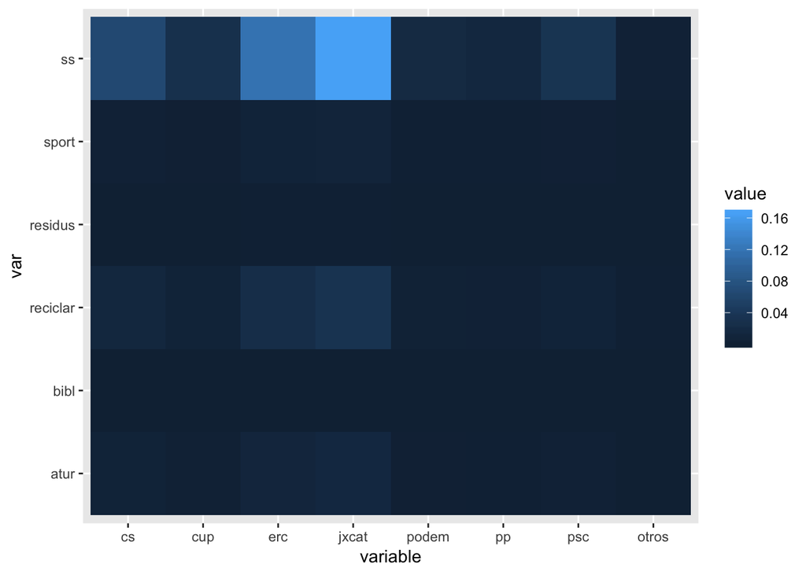

```r
library(ggplot2)
ggplot(grafic.m, aes(x = variable, y = var , fill = value)) + geom_tile()
```

```r
grafic = select(df.munvar, ss:residus, unionistes, indepes) %>%
  gather(var, pes, ss:residus) %>%
  mutate(unionistes = unionistes*pes) %>% mutate(indepes = indepes * pes)
grafic
```

```
## # A tibble: 5,682 x 4
##    unionistes indepes var     pes
##         <dbl>   <dbl> <chr> <dbl>
##  1     0.268    0.138 ss    0.465
##  2     0.0632   0.422 ss    0.487
##  3     0.149    0.257 ss    0.434
##  4     0.0208   0.465 ss    0.502
##  5     0.142    0.309 ss    0.479
##  6     0.129    0.269 ss    0.421
##  7     0.0999   0.321 ss    0.446
##  8     0.0567   0.425 ss    0.498
##  9     0.158    0.263 ss    0.450
## 10     0.120    0.318 ss    0.459
## # … with 5,672 more rows
```

```r
library(ggpubr)
```

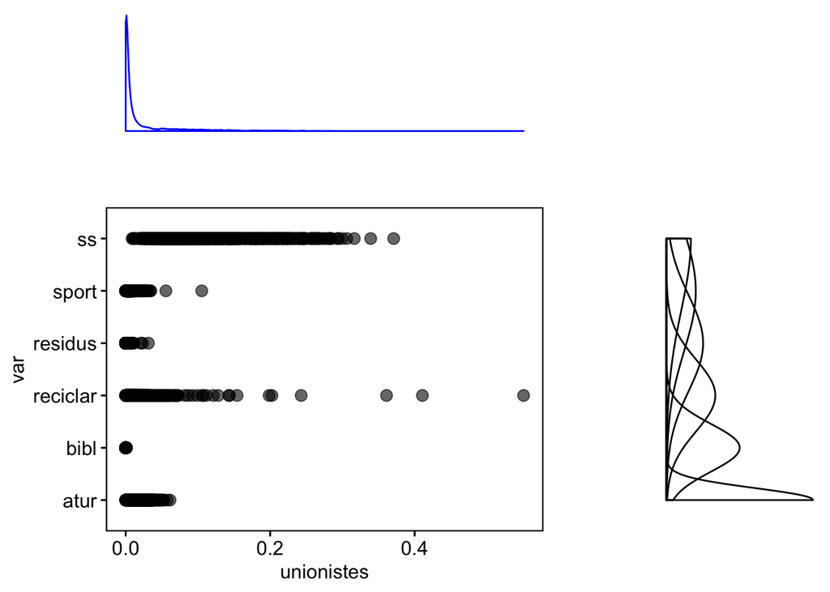

```r
sp <- ggscatter(grafic, x = "unionistes", y = "var",
                palette = "jco",
                size = 3, alpha = 0.6)+
  border()
# Marginal density plot of x (top panel) and y (right panel)
xplot <- ggdensity(grafic, "unionistes", fill = "unionistes",
                   color = "blue", palette = "jco")
yplot <- ggdensity(grafic, "var", fill = "unionistes",
                   palette = "jco")+
  rotate()
# Cleaning the plots
yplot <- yplot + clean_theme()
xplot <- xplot + clean_theme()
# Arranging the plot
ggarrange(xplot, NULL, sp, yplot,
          ncol = 2, nrow = 2,  align = "hv",
          widths = c(2, 1), heights = c(1, 2),
          common.legend = FALSE)
```

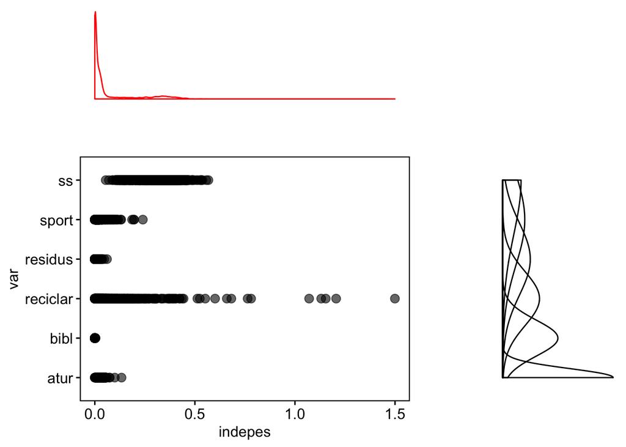

```r
sp <- ggscatter(grafic, x = "indepes", y = "var",
                palette = "jco",
                size = 3, alpha = 0.6)+
  border()
# Marginal density plot of x (top panel) and y (right panel)
xplot <- ggdensity(grafic, "indepes", fill = "indepes",
                   color = "red", palette = "jco")
yplot <- ggdensity(grafic, "var", fill = "indepes",
                   palette = "jco")+
  rotate()
# Cleaning the plots
yplot <- yplot + clean_theme()
xplot <- xplot + clean_theme()
# Arranging the plot
ggarrange(xplot, NULL, sp, yplot,
          ncol = 2, nrow = 2,  align = "hv",
          widths = c(2, 1), heights = c(1, 2),
          common.legend = FALSE)
```

El contingut a continuació són fragments de codi que s’ha anat explorant al llarg de la pràctica però que he decidit descartar.

Creem un nou objecte que identifica i acumnula -si n’hi ha- els valors NA per tal que els puguem processar fàcilment en bloc si es requerís a posteriori, malgrat en aquest cas no seria necessari. NV <- sapply(grafic, function(x) sum(is.na(x)));NV[NV>0] NV

NV <- sapply(grafic, function(x) sum(is.na(x)));NV[NV>0]

grafic <- remove_missing(grafic, na.rm = TRUE)

grafic <- data.matrix(grafic)

Preparem la taula que dibuixarà el gràfic, seleccionem els pesos relatius de cada variable i multipliqum amb el pes relatiu obtingut per cada partit grafic = select(df.munvar, ss:residus, unionistes, indepes) %>% gather(var, pes, ss:residus) %>% arrange (var, desc(pes)) %>% mutate(unionistes= unionistes*pes) %>% mutate(indepes = indepes* pes) grafic

ideologia <- grafic[2:3]

NV <- sapply(grafic, function(x) sum(is.na(x)));NV[NV>0]

grafic <- remove_missing(grafic, na.rm = TRUE)

column_to_rownames(grafic, var = “var”) grafic <- data.matrix(grafic)

library(ggplot2) ggplot(as.data.frame(grafic), aes(x = var, y = , fill = pes)) + geom_tile()

Creem un dataframe que relaciona les variables de poble amb el pes en vots de cada partit al poble munvar_par <- select(pregrafic,ss:residus, vots) %>% mutate_all(funs(.* vots))

Creem el dataframe amb dades relatives de partit, població i variables del poble grafic1 <- data.frame(partit = pregrafic$partit,munvar_par) grafic1

Provem un heatmap amb una llibreria que hem trobat a la xarxa. https://rlbarter.github.io/superheat/index.html

superheat(select(grafic1, ss, atur), scale=TRUE)

[output not shown]

grafic1u <- filter(grafic1, partit == “unionistes”)

ggplot(grafic11, aes(x = vots, y = as.factor(ss:residus), fill = partit)) + geom_density_ridges2()

ggplot(grafic1, aes(x = `Mean Temperature [F]`, y = `P`, fill = ..x..)) + geom_density_ridges_gradient(scale = 3, rel_min_height = 0.01) + scale_fill_viridis(name = “Temp. [F]”, option = “C”) + labs(title = ‘Temperatures in Lincoln NE in 2016’)